# clustra: Graphics with BP Data

Nimish Adhikari, George Ostrouchov, Hanna Gerlovin, and David Gagnon

2024-01-08

The **clustra** package was built to **clus**ter medical **tra**jectories (time series) related by an intervention time. This vignette is intended to reproduce the results of an associated paper “clustra: A multi-platform k-means clustering algorithm for analysis of longitudinal trajectories in large electronic health records data.”

To run the paper version, set `chunk = figs` and `full_data = TRUE` in the first code chunk below. It takes about 70 minutes with `mc = 5` on a Quad-Core I7, and requires Internet access to get the full data from GitHub. The default for CRAN submission is limited to a sample of about 1/8 of the full data set to satisfy CRAN limits on package data size and runs a smaller subset of the code chunks (takes about 40 seconds).

Additional plots to explain the methodology and examine the data can be produced by setting `chunk = all` in the chunk below. This will run over 2 hours with the same system configuration.

Below is the code that controls which code chunks are evaluated and how many cores to use.

```r
knitr::opts_knit$set(
  collapse = TRUE,
  comment = "#>"
)
cran = list(LibsData = TRUE, plot_true = TRUE, plot_raw = TRUE, run5 = TRUE, run5_v2 = FALSE, iter_plots = TRUE, plot5_side_by_side = FALSE, fig1 = FALSE, comp_true = FALSE, run10 = FALSE, plot10 = FALSE, run2 = FALSE, rand2 = FALSE, silplot = FALSE, silplot2 = FALSE, rand_plot = FALSE, hclust40 = FALSE, SAS_R_data = FALSE, Rand_SAS_R = FALSE, true_group = FALSE)
figs = list(LibsData = TRUE, plot_true = FALSE, plot_raw = FALSE, run5 = TRUE, run5_v2 = TRUE, iter_plots = FALSE, plot5_side_by_side = FALSE, fig1 = TRUE, comp_true = TRUE, run10 = TRUE, plot10 = TRUE, run2 = TRUE, rand2 = TRUE, silplot = TRUE, silplot2 = FALSE, rand_plot = TRUE, hclust40 = FALSE, SAS_R_data = TRUE, Rand_SAS_R = TRUE, true_group = TRUE)
all = list(LibsData = TRUE, plot_true = TRUE, plot_raw = TRUE, run5 = TRUE, run5_v2 = TRUE, iter_plots = TRUE, plot5_side_by_side = TRUE, fig1 = TRUE, comp_true = TRUE, run10 = TRUE, plot10 = TRUE, run2 = TRUE, rand2 = TRUE, silplot = TRUE, silplot2 = TRUE, rand_plot = TRUE, hclust40 = TRUE, SAS_R_data = TRUE, Rand_SAS_R = TRUE, true_group = TRUE)
chunk = cran  # chose which version of the vignette to run
full_data = FALSE # choose if full 80,000 id data or sample of 10,000 ids
mc = 2
# If running on a Unix or a Mac platform, set to number of available cores.
# This vignette will experience notable speedup up to about 10 cores.
# On Intel chips with hyperthreading, up to 2x available cores can be used.
if (.Platform$OS.type == "windows") mc = 1

data.table::setDTthreads(1) # manage data.table threads (increase with full_data)
```

We start by loading the `clustra` package and getting the data. We also set the output path for plots to `tempdir()`, which should be changed to a user directory if they are needed beyond the Knit output.

```r
library(clustra)
start_time = deltime()
print(paste("Number of cores being used: mc parameter =", mc))
```

```
## [1] "Number of cores being used: mc parameter = 2"
```

```r
repo = "https://github.com/MVP-CHAMPION/"

repo_sas = paste0(repo, "clustra-SAS/raw/main/")
if(full_data) {
  url = paste0(repo_sas, "bp_data/simulated_data_27June2023.csv.gz")
  data = data.table::fread(url)
} else {
  data = bp10k
}
data$true_group = data$group
head(data)
```

```
##    id group time response true_group
## 1: 18     3  -21 176.9072          3
## 2: 18     3   22 154.3234          3
## 3: 18     3  324 107.2318          3
## 4: 18     3  353 130.8007          3
## 5: 18     3  373 137.3623          3
## 6: 18     3  391 130.8484          3
```

```r
plot_path = paste0(tempdir(), "/") # output dir for plots
cat("Resulting plots are saved in", plot_path, "directory\n")
```

```
## Resulting plots are saved in /var/folders/1t/x5sdn3gs653fr7k6vz6jq3l80000gn/T//RtmpHUZluf/ directory
```

Select a few random `id`s and print their scatterplots colored by `true_group`. This only displays 9 individuals. The data was generated based on five clusters. As the data used to simulate this synthetic dataset is extremely noisy, it would be difficult to ascertain any patterns by looking at a few subjects.

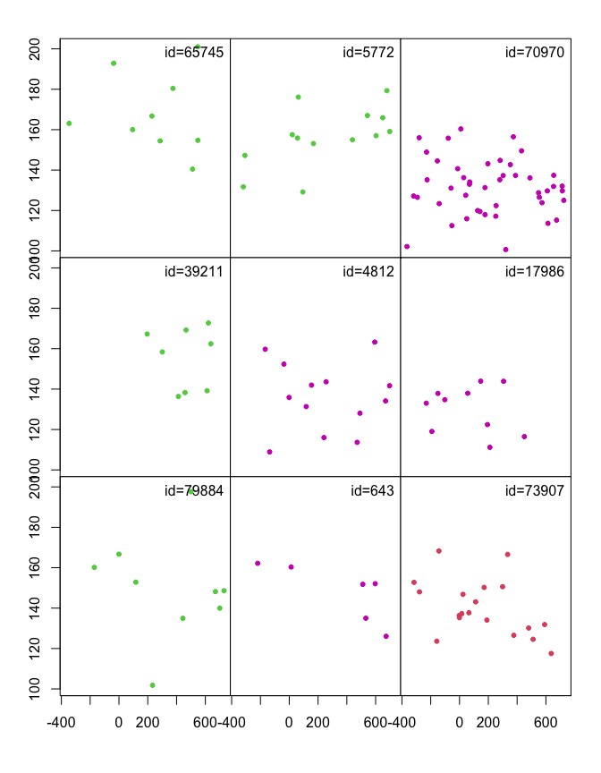

```r
set.seed(12345)
plot_sample(data, layout = c(3, 3), group = "true_group")
```

Now plot a 20,000 sample of the raw data. Use the true or simulated group assignment for coloring. As we can see, there is a lot of noise and it would be difficult to identify the clusters of trajectories by looking at the individual points, alone. A greater density of points is seen at time 0, where all trajectories have a data point.

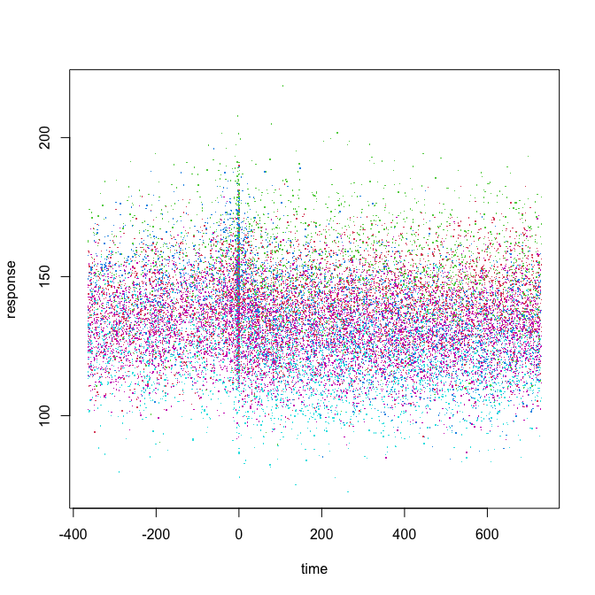

```r
plot_smooths(data, fits = NULL, max.data = 20000, group = "true_group")
```

Next, cluster the trajectories. Set `k=5`, spline max degrees of freedom to 30, and maximum iterations to 20. Initial cluster assignments are the default “random”. We print out full information for the iterations, including the elapsed time.

```r
set.seed(12345)
cl5 = clustra(data, k = 5, maxdf = 30, conv = c(20, 0.5), mccores = mc, verbose = TRUE)
```

```
##   Start counts 2001 2004 2016 2010 1969   Starts time: 0
##  1 (M-123)-0.57 (E-12345)-0.47 Changes: 7797 Counts: 1257 820 3529 1099 3295 Deviance: 46903674
##  2 (M-123)-0.31 (E-12345)-0.26 Changes: 2413 Counts: 1373 1774 2712 1450 2691 Deviance: 34739540
##  3 (M-123)-0.26 (E-12345)-0.46 Changes: 1405 Counts: 1384 2495 2156 1549 2416 Deviance: 33236379
##  4 (M-123)-0.31 (E-12345)-0.41 Changes: 938 Counts: 1407 2925 1814 1621 2233 Deviance: 32517385
##  5 (M-123)-0.31 (E-12345)-0.33 Changes: 645 Counts: 1466 3080 1633 1762 2059 Deviance: 32187814
##  6 (M-123)-0.26 (E-12345)-0.41 Changes: 741 Counts: 1536 3031 1549 2011 1873 Deviance: 32013822
##  7 (M-123)-0.31 (E-12345)-0.32 Changes: 929 Counts: 1624 2932 1486 2299 1659 Deviance: 31769678
##  8 (M-123)-0.26 (E-12345)-0.4 Changes: 898 Counts: 1728 2851 1439 2497 1485 Deviance: 31317772
##  9 (M-123)-0.26 (E-12345)-0.25 Changes: 517 Counts: 1857 2846 1401 2490 1406 Deviance: 30949472
##  10 (M-123)-0.26 (E-12345)-0.33 Changes: 220 Counts: 1923 2859 1386 2459 1373 Deviance: 30831685
##  11 (M-123)-0.26 (E-12345)-0.34 Changes: 82 Counts: 1952 2869 1382 2434 1363 Deviance: 30811168
##  12 (M-123)-0.31 (E-12345)-0.32 Changes: 37 Counts: 1971 2876 1380 2415 1358 Deviance: 30807849
##  AIC:424.11 BIC:1627.1 edf:119.97  Total time: -8.15  converged
```

```r
# What happens if we cut the iterations at 5 maximum?
set.seed(12345)
cl5.v2 = clustra(data, k = 5, maxdf = 30, conv = c(5, 0.5), mccores = mc)
```

Setting the option `verbose = 2` produces plots of the cluster spline centers at every iteration. We also pass the `ylim` parameter because the yaxis extent of the data is much wider than the models.

```r
set.seed(12345)
clustra(data, k = 5, maxdf = 30, conv = c(10, 0.5), mccores = mc, verbose = 2, ylim = c(110, 170))
```

```
##   Start counts 2001 2004 2016 2010 1969   Starts time: 0
##  1 (M-123)-0.3 (E-12345)-0.33 Changes: 7797 Counts: 1257 820 3529 1099 3295 Deviance: 46903674
```

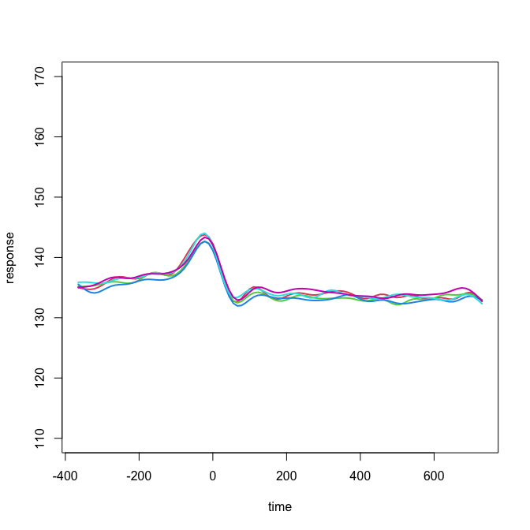

```
##
##  2 (M-123)-0.33 (E-12345)-0.26 Changes: 2413 Counts: 1373 1774 2712 1450 2691 Deviance: 34739540
```

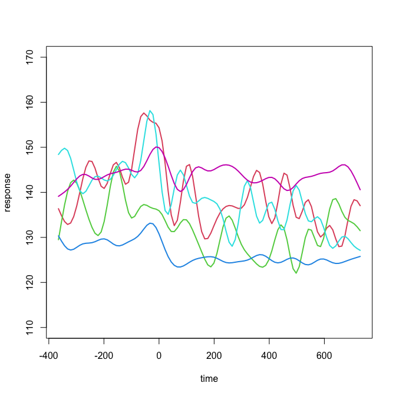

```
##
##  3 (M-123)-0.34 (E-12345)-0.25 Changes: 1405 Counts: 1384 2495 2156 1549 2416 Deviance: 33236379
```

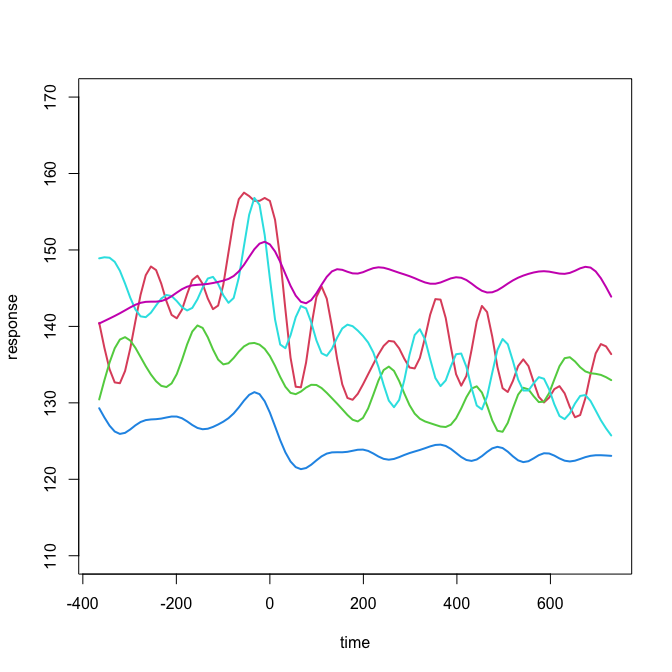

```
##
##  4 (M-123)-0.28 (E-12345)-0.26 Changes: 938 Counts: 1407 2925 1814 1621 2233 Deviance: 32517385
```

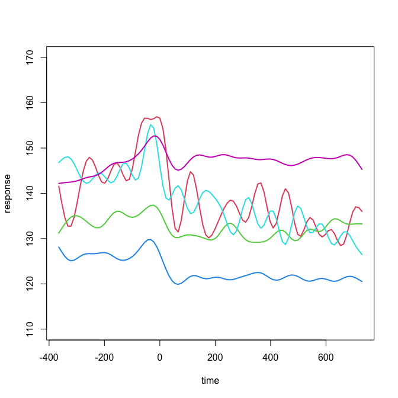

```
##
##  5 (M-123)-0.33 (E-12345)-0.32 Changes: 645 Counts: 1466 3080 1633 1762 2059 Deviance: 32187814
```

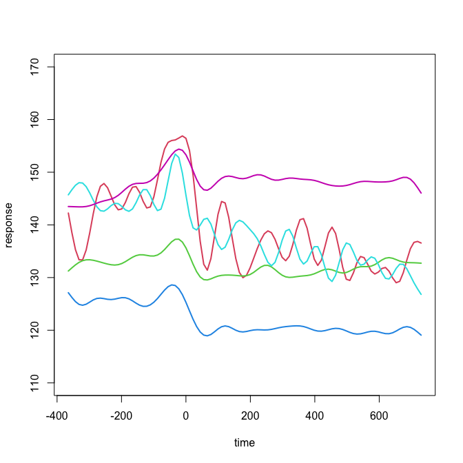

```
##
##  6 (M-123)-0.29 (E-12345)-0.47 Changes: 741 Counts: 1536 3031 1549 2011 1873 Deviance: 32013822
```

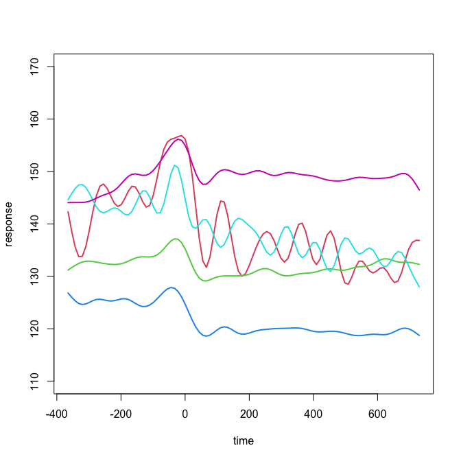

```
##
##  7 (M-123)-0.28 (E-12345)-0.33 Changes: 929 Counts: 1624 2932 1486 2299 1659 Deviance: 31769678
```

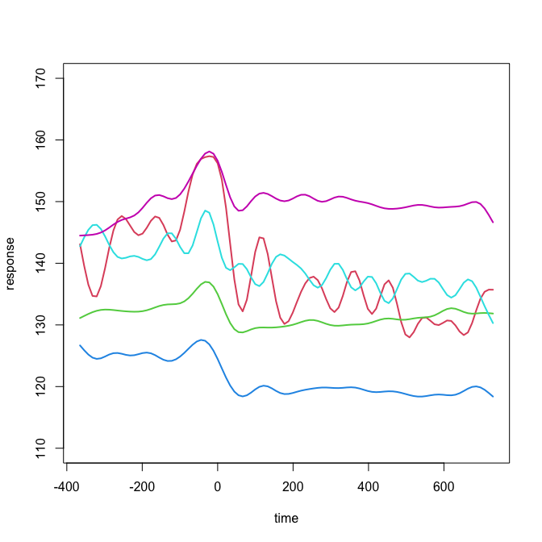

```
##
##  8 (M-123)-0.34 (E-12345)-0.26 Changes: 898 Counts: 1728 2851 1439 2497 1485 Deviance: 31317772
```

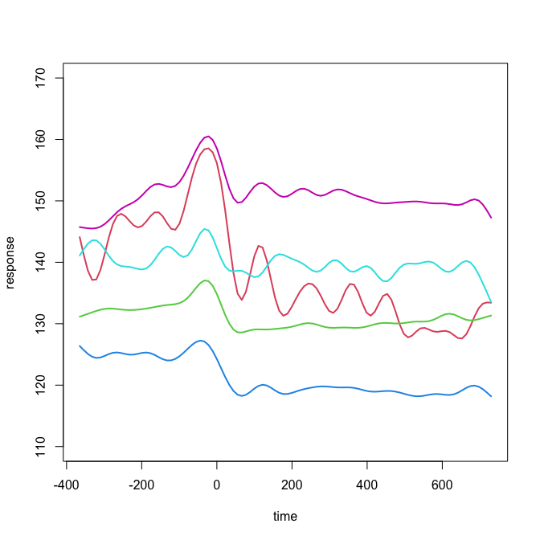

```
##
##  9 (M-123)-0.28 (E-12345)-0.26 Changes: 517 Counts: 1857 2846 1401 2490 1406 Deviance: 30949472
```

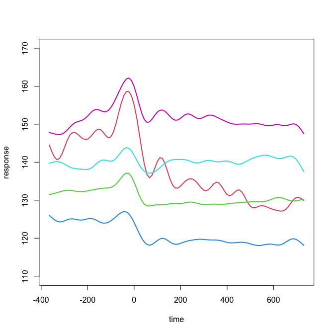

```
##
##  10 (M-123)-0.29 (E-12345)-0.34 Changes: 220 Counts: 1923 2859 1386 2459 1373 Deviance: 30831685
```

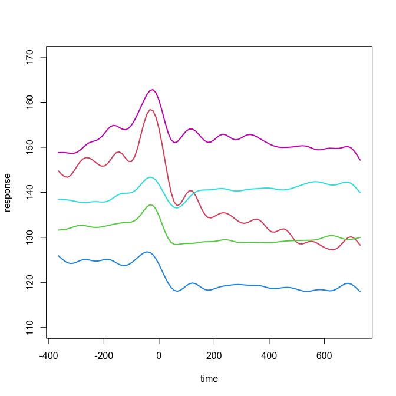

```
##
##  AIC:425.11 BIC:1632.81 edf:120.44  Total time: -6.4  max-iter
```

Test producing two side-by-side plots.

```r
plot_smooths(data, fits = cl5$tps, max.data = 30000)
m = matrix(c(0.1, .95, 0.1, .95), nrow = 1)
sc = split.screen(m)
screen(1)
  sc = split.screen(c(1, 2))
  screen(2)
    plot_smooths(data, fits = cl5$tps, max.data = 0, ylim = c(110, 180))
  screen(3)
    plot_smooths(data, fits = cl5.v2$tps, max.data = 0, ylim = c(110, 180))
close.screen(all.screens = TRUE)
```

This is Figure 1 in the paper.

```r
png(paste0(plot_path, "R_cl5_plot.png"), width = 480, height = 360)
    plot_smooths(data, fits = cl5$tps, max.data = 0, ylim = c(110, 180))
dev.off()
knitr::include_graphics(paste0(plot_path, "R_cl5_plot.png"))
```

Compute the Rand index for comparing with true_groups and with each other.

```r
MixSim::RandIndex(cl5$data_group, data[, true_group])$AR
MixSim::RandIndex(cl5.v2$data_group, data[, true_group])$AR
MixSim::RandIndex(cl5$data_group, cl5.v2$data_group)$AR
```

Next, we try requesting too many clusters in the noisy data.

```r
set.seed(12345)
t = deltime()
cl10 = clustra(data, k = 10, maxdf = 30, conv = c(50, 0.5), mccores = mc)
deltimeT(t, paste("run time on", mc, "cores "))
```

Next, plot the resulting fit. This is Figure 2 in the paper.

```r
png(paste0(plot_path, "R_cl10_plot.png"), width = 480, height = 360)
  plot_smooths(data, cl10$tps, max.data = 0, ylim = c(110, 180))
dev.off()
knitr::include_graphics(paste0(plot_path, "R_cl10_plot.png"))
MixSim::RandIndex(cl10$data_group, data[, true_group])$AR
```

Next, we look at what the clusters would look like with 2 groups and plot the result. This is figure 3 in the paper.

```r
set.seed(12345)
t = deltime()
cl2 = clustra(data, k = 2, maxdf = 30, conv = c(20,0.5), mccores=mc)
deltimeT(t, paste(" run time on", mc, "cores "))
cat(paste("Number of iterations completed:",cl2$iterations))
cat(paste("Number of individuals changing groups in last iteration:",cl2$changes))
png(paste0(plot_path, "R_cl2_plot.png"), width = 480, height = 360)
  plot_smooths(data, cl2$tps, max.data = 0, ylim = c(110, 180))
dev.off()
knitr::include_graphics(paste0(plot_path, "R_cl2_plot.png"))
MixSim::RandIndex(cl2$data_group, data[, true_group])$AR
```

Compute the Adjusted Rand Index between the various results.

```r
MixSim::RandIndex(cl5$data_group,cl2$data_group)$AR
MixSim::RandIndex(cl5$data_group,cl10$data_group)$AR
MixSim::RandIndex(cl10$data_group,cl2$data_group)$AR
```

Average silhouette value is a way to select the number of clusters and a silhouette plot provides a way for a deeper evaluation (Rouseeuw 1986). A true silhouette requires distances between individual trajectories, which is not possible here due to unequal trajectory sampling without fitting a separate model for each id. As a proxy for distance between points, we use trajectory distances to cluster mean spline trajectories in the `clustra_sil()` function. The structure returned from the `clustra()` function contains the matrix `loss`, which has all the information needed to construct these proxy silhouette plots. The function `clustra_sil()` performs clustering for a number of `k` values and outputs information for the silhouette plot that is displayed next.

These plots are Figure 4, 5, and 6 in the paper.

```r
t = deltime()

sil = clustra_sil(cl5, mccores = mc, conv=c(20,0.5))
png(paste0(plot_path, "R_cl5_silplot.png"), width = 480, height = 360)
  lapply(sil, plot_silhouette)
dev.off()
set.seed(12345)
sil2 = clustra_sil(cl2, mccores = mc, conv=c(20,0.5))
png(paste0(plot_path, "R_cl2_silplot.png"), width = 480, height = 360)
  lapply(sil2, plot_silhouette)
dev.off()
set.seed(12345)
sil10 = clustra_sil(cl10, mccores = mc, conv=c(20,0.5))
png(paste0(plot_path, "R_cl10_silplot.png"), width = 480, height = 360)
  lapply(sil10, plot_silhouette)
dev.off()
knitr::include_graphics(paste0(plot_path, "R_cl5_silplot.png"))
knitr::include_graphics(paste0(plot_path, "R_cl2_silplot.png"))
knitr::include_graphics(paste0(plot_path, "R_cl10_silplot.png"))
deltimeT(t, paste(" silhouettes on", mc, "cores "))
```

Here we produce silhouettes directly from the data, which runs clustra internally.

```r
# Example running from the data step
t = deltime()
set.seed(12345)
sil = clustra_sil(data, k = c(2, 5, 10), mccores = mc, conv = c(50, 0.5))
lapply(sil, plot_silhouette)
deltimeT(t, paste("Silhouettes and clustra on", mc, "cores "))
```

```r
t = deltime()
set.seed(12345)
ran = clustra_rand(data, k = seq(2, 10, 1), starts = "random", mccores = mc,
                   replicates = 10, conv=c(40,0.5), verbose = TRUE)
deltimeT(t, paste(" clustra_rand on", mc, "cores "))
rand_plot(ran, name = paste0(plot_path, "R_randplot.pdf")) # save pdf version
rand_plot(ran) # render png version
```

Another possible evaluation of the number of clusters is to first ask clustra for a large number of clusters, evaluate the cluster centers on a common set of time points, and feed the resulting matrix to a hierarchical clustering function. Below, we ask for 40 clusters and the `hclust()` function clusters the 40 resulting cluster means, each evaluated on 100 time points.

```r
gpred = function(tps, newdata) {
  as.numeric(mgcv::predict.bam(tps, newdata, type = "response",
                               newdata.guaranteed = TRUE))
}
```

```r
set.seed(12345)
t = deltime()
cl40 = clustra(data, k = 40, maxdf = 30, conv = c(100,0.5), mccores = mc, verbose = TRUE)
timep = data.frame(time = seq(min(data$time), max(data$time), length.out = 100))
resp = do.call(rbind, lapply(cl40$tps, gpred, newdata = timep))
png(paste0(plot_path, "R_hclust_plot.png"), width = 720, height = 480)
  plot(hclust(dist(resp)))
dev.off()
knitr::include_graphics(paste0(plot_path, "R_hclust_plot.png"))
deltimeT(t, paste("clustra k = 40, conv = c(100, 0.5) on", mc, "cores + hclust + dist "))
```

## Comparison between SAS and R clustering

Look at the data output from the SAS clustering analysis. Since SAS and R produce different cluster labels, we need to relabel and replot the SAS data output, which is on the https://github.com/MVP-CHAMPION/clustra-SAS repository. The mapping algorithm in `sas_r_cplot()` below matches SAS and R pairs by distance, starting with shortest distance pair, and then plots the pairs with matching colors.

```r
sas.file = function(file, rp = repo_sas) paste0(rp, "sas_results/", file)

sas_r_cplot = function(file, clustra_out) {
  sas = cbind(haven::read_sas(sas.file(file)), source = 1)
  r = data.frame(time = min(sas$time):max(sas$time))
  n = nrow(r)
  k = nrow(sas)/n
  ## below assumes same time in each group and groups are contiguous.
  rpred = do.call(c, parallel::mclapply(clustra_out$tps, gpred, newdata = r,
                                        mc.cores = mc))

  ## compute mapping from SAS to R using manhattan distance over time
  rmap = vector("integer", k)
  m = as.matrix(
    dist(rbind(t(matrix(sas$pred, n)),
               t(matrix(rpred, nrow = n))), "manhattan"))[1:k, (k + 1):(2*k)]
  for(i in 1:k) { # assign starting with closest pair
    ind = arrayInd(which.min(m), dim(m))
    rmap[ind[1]] = ind[2]
    m[ind[1], ] = Inf
    m[, ind[2]] = Inf
  }

  r = cbind(r, group = sas$group, pred = rpred, source = 2)
  plot(pred ~ time, data = sas, type = "n")
  for(i in 1:k) {
    sr = (1 + (i - 1)*n):(i*n)
    rr = (1 + (rmap[i] - 1)*n):(rmap[i]*n)
    lines(sas[sr, ]$time, sas[sr, ]$pred, lty = sas[sr, ]$source, col = i)
    lines(r[rr, ]$time, r[rr, ]$pred, lty = r[rr, ]$source, col = i)
  }
  rmap # output the mapping from SAS clusters to R: R = rmap[SAS]
}
png(paste0(plot_path, "R_SAS_cl2_compare.png"), width = 480, height = 360)
  map2 = sas_r_cplot("graphout_cl2.sas7bdat", cl2)
dev.off()
png(paste0(plot_path, "R_SAS_cl5_compare.png"), width = 480, height = 360)
  map5 = sas_r_cplot("graphout_cl5.sas7bdat", cl5)
dev.off()
png(paste0(plot_path, "R_SAS_cl10_compare.png"), width = 480, height = 360)
  map10 = sas_r_cplot("graphout_cl10.sas7bdat", cl10)
dev.off()
knitr::include_graphics(paste0(plot_path, "R_SAS_cl2_compare.png"))
knitr::include_graphics(paste0(plot_path, "R_SAS_cl5_compare.png"))
knitr::include_graphics(paste0(plot_path, "R_SAS_cl10_compare.png"))
```

Next, check the Rand index comparing R and SAS results:

```r
MixSim::RandIndex(haven::read_sas(sas.file("rms_cl2.sas7bdat"))$newgroup, cl2$group)
MixSim::RandIndex(haven::read_sas(sas.file("rms_cl5.sas7bdat"))$newgroup, cl5$group)
MixSim::RandIndex(haven::read_sas(sas.file("rms_cl10.sas7bdat"))$newgroup, cl10$group)
```

Now compare with true_group used to generate the data:

```r
true_group = data[, mean(true_group),by=id]
MixSim::RandIndex(haven::read_sas(sas.file("rms_cl5.sas7bdat"))$newgroup, true_group$V1)
MixSim::RandIndex(true_group$V1, cl5$group)
```

### Some notes about the SAS execution and results

- Generated using v14R1 macros
- Currently using the method=0 (GAMPL with default optimization, NOT thin plate splines)
- No current random seed allocation, thus results may vary between executions/runs (related to the note above, this would require manual updates on next execution)

```
## clustra vignette run time -14.8 seconds
```